# 04-world-series-home-field

Yasi Wang

9/15/2019

[figure not shown]

In this blog, I will continue talking about **discrete probability calculations** and **World Series**.

# Introduction

### World Series

**The World Series** is a first-to-4-wins match-up between the champions of the American and National Leagues of Major League Baseball. The game will take place in both two teams’ home stadium. PLaying at home or away home will definitely affect the team’s winning probability.

### Home field advantage

**The home field advantage** is the edge which a team may have when playing a game at its home stadium. For example, it is the edge the Braves may have over the Yankees when the head-to-head match-up is in Atlanta. It is the advantage the Yankees may have when the head-to-head match-up is in New York.

In this blog, I’m going to use simulation and analytic methods to compare the probability of winning the World Series with and without home field advantage.

# Setup

### Schedule for each game of the series

In a best-of-7 match-up series, one possible schedule is

|  | Game 1 | Game 2 | Game 3 | Game 4 | Game 5 | Game 6 | Game 7 |
| --- | --- | --- | --- | --- | --- | --- | --- |
| Location | NYC | NYC | ATL | ATL | ATL | NYC | NYC |
| Home field | Y | Y | B | B | B | Y | Y |

### Probability that the Braves win a single game

| Game location | No advantage | Advantage |
| --- | --- | --- |
| ATL | *P*<sub>*B*</sub> | *P*<sub>*B*</sub><sup>*H*</sup> = *P*<sub>*B*</sub> * 1.1 |
| NYC | *P*<sub>*B*</sub> | *P*<sub>*B*</sub><sup>*A*</sup> = 1 - (1 - *P*<sub>*B*</sub>) * 1.1 |

# Statistical Computation

### Without home field advantage

Assuming *P*<sub>*B*</sub> = 0.55, P(Braves wiin the series) = 0.608.

```r
p1 <- pnbinom(3,4,.55)
```

### With home field advantage

*P*<sub>*B*</sub><sup>*H*</sup> = 0.605, *P*<sub>*B*</sub><sup>*A*</sup> = 0.505, P(Braves wiin the series) = 0.604.

```r
# Get all possible outcomes
apo <- data.table::fread("all-possible-world-series-outcomes.csv")

# Home field indicator
hfi <- c(0,0,1,1,1,0,0) #{NYC, NYC, ATL, ATL, ATL, NYC, NYC}

# P_B
pb <- 0.55
advantage_multiplier <- 1.1 # Set = 1 for no advantage
pbh <- 0.55*advantage_multiplier
pba <- 1 - (1 - 0.55)*advantage_multiplier

# Calculate the probability of each possible outcome
apo[, p := NA_real_] # Initialize new column in apo to store prob
for(i in 1:nrow(apo)){
  prob_game <- rep(1, 7)
  for(j in 1:7){
    p_win <- ifelse(hfi[j], pbh, pba)
    prob_game[j] <- case_when(
        apo[i,j,with=FALSE] == "W" ~ p_win
      , apo[i,j,with=FALSE] == "L" ~ 1 - p_win
      , TRUE ~ 1
    )
  }
  apo[i, p := prod(prob_game)] # Data.table syntax
}


# Probability of overall World Series outcomes
p2 <- apo[, sum(p), overall_outcome][[2]][[1]]
```

# Simulation

### Without VS without home advantage

Assuming that *P*<sub>*B*</sub> = 0.55, when we simulate 100000 series, the probability that Braves win the series is:

|  | without home field advantage | with home field advantage | difference |
| --- | --- | --- | --- |
| probability | 0.609 | 0.607 | 0.002 |

The difference is due to whether counting home field advantage as a factor. Because in this series, Braves only has three home field games, which means it loses home field advantage in the overall series of game. Thus, if we take home field advantage in to consideration, the probability that Braves win the series will decrease.

```r
# without home advantage

set.seed(123)
pb = 0.55
p_1 <- rep(NA, 100000)
count = 0
for (i in 1:100000) {
  p_1[i] <- rbinom(1,7,.55)
  if (p_1[i] >= 4) {
    count = count + 1
  }
  p3 = count / 100000
}
```

```r
# with home advantage

set.seed(10)
p_array = c(0.505, 0.505, 0.605, 0.605, 0.605, 0.505, 0.505)

count = 0
for (i in 1:100000) {
  tmp <- 0
  for (j in 1:7){
    tmp = tmp + rbinom(1,1, p_array[j])
  }

  if (tmp >= 4) {
    count = count + 1
  }
  p4 = count / 100000
}
```

# Absolute error and relative error

### Without home advantage

```r
abs_error_1 <- abs(p3 - p1)
rel_error_1 <- abs_error_1/p1
```

### With home advantage

```r
abs_error_2 <- abs(p4 - p2)
rel_error_2 <- abs_error_2/p2
```

# Factors that affect the difference in winning probabilites

### 1) *P*<sub>*B*</sub>

The graph below shows the relationship: As *P*<sub>*B*</sub> increases (from 0.51 to 1), the winning probability with home field advantage will first increase and then decrease. Correspondingly, the difference will first increase from -0.0134 to 0.018 (estimated) and then decrease to 0.

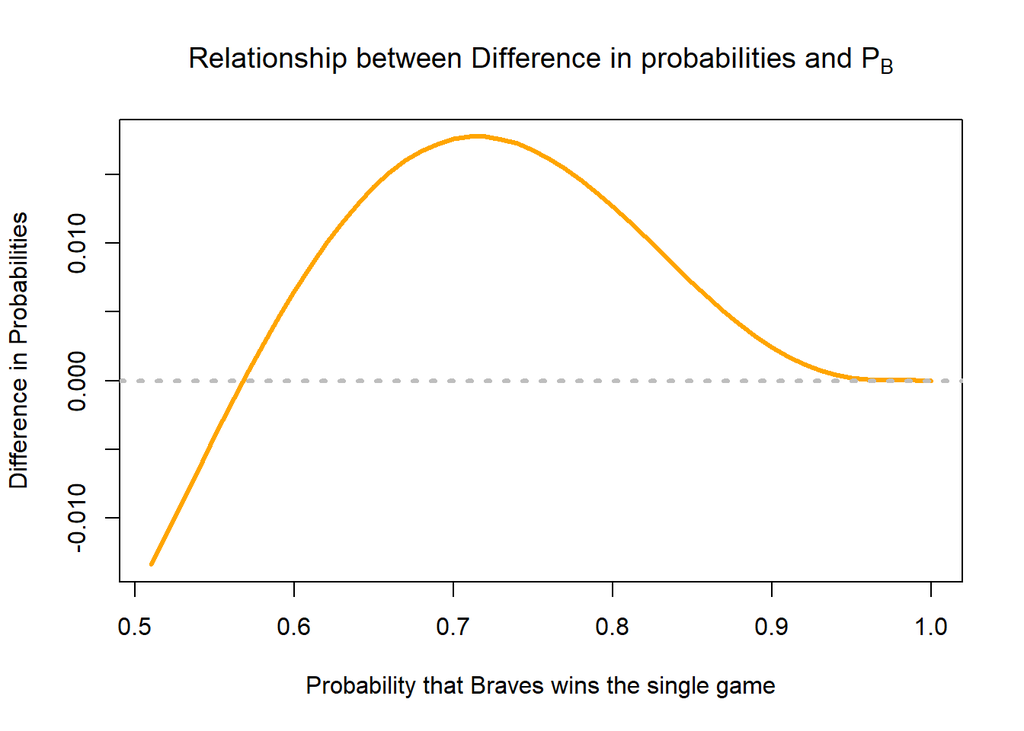

```r
apo <- data.table::fread("all-possible-world-series-outcomes.csv")
hfi <- c(0,0,1,1,1,0,0) #{NYC, NYC, ATL, ATL, ATL, NYC, NYC}
diff1 <- function(x) {
  p_without <- pnbinom(3,4,x)
  pbh <- x*1.1
  pba <- 1 - (1 - x)*1.1

  apo[,p :=NA_real_]
  for (i in 1:nrow(apo)) {
    prob_game <- rep(1, 7)
    for (j in 1:7) {
      p_win <- ifelse(hfi[j], pbh, pba)
      prob_game[j] <- case_when(
        apo[i,j,with=FALSE] == "W" ~ p_win
        , apo[i,j,with=FALSE] == "L" ~ 1 - p_win
        , TRUE ~ 1)
    }
    apo[i, p := prod(prob_game)]
  }
  p_with <- apo[, sum(p), overall_outcome][[2]][[1]]
  return(p_with - p_without)
}

d1 <- rep(NA, 50)
prob <- seq(0.51, 1, 0.01)

for (i in 1:50) {
  d1[i] <- diff1(prob[i])
}

plot(x = prob, y = d1, type = 'l', lwd = 3, col = "orange", xlab = "Probability that Braves wins the single game", ylab = "Difference in Probabilities", main = TeX("Relationship between Difference in probabilities and $P_B$"))
abline(h = 0, col = "gray", lty = 3, lwd = 3)
```

### 2) Advantage multiplier

Advantage factor may also affect the difference in probabilites (with vs without home field advantage). diff2 function describes the relationship between advantage multiplier (ranges from 1 to 1.8) and the probability difference.

The graph tells us that 1) when advantage multiplier = 1, difference = 0. 2) as the multiplier increases, the probability of Braves winning the whole series will decrease with home field advantage. 2) thus, the difference in probabilities between with or without home field advantage will decrease.

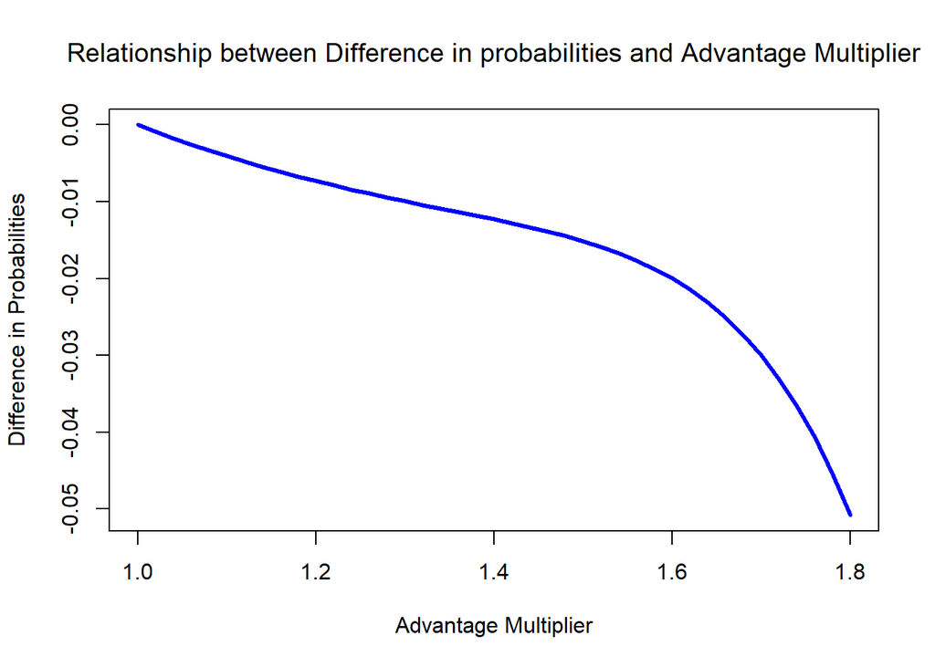

```r
diff2 <- function(x) {

  p_without <- pnbinom(3,4,.55)

  pbh <- .55*x
  pba <- 1 - (1 - .55)*x

  apo[,p :=NA_real_]
  for (i in 1:nrow(apo)) {
    prob_game <- rep(1, 7)
    for (j in 1:7) {
      p_win <- ifelse(hfi[j], pbh, pba)
      prob_game[j] <- case_when(
        apo[i,j,with=FALSE] == "W" ~ p_win
        , apo[i,j,with=FALSE] == "L" ~ 1 - p_win
        , TRUE ~ 1
      )
    }
    apo[i, p := prod(prob_game)]
  }
  p_with <- apo[, sum(p), overall_outcome][[2]][[1]]
  return(p_with - p_without)
}

d2 <- rep(NA, 41)
adv <- seq(1, 1.8, 0.02)

for (i in 1:41) {
  d2[i] <- diff2(adv[i])
}

plot(x = adv, y = d2, type = 'l', lwd = 3, col = "blue", xlab = "Advantage Multiplier", ylab = "Difference in Probabilities", main = TeX("Relationship between Difference in probabilities and Advantage Multiplier"))
```